# OPTIMISATION DE LA TARIFICATION EN ASSURANCE GRÂCE À L’AUTOCALIBRATION : ÉTUDE COMPARATIVE DES MODÈLES GLM, GAM ET GBM

[figure not shown]

# 1 Fonctions

## 1.1 Multiplot

```r
 # Charger les bibliothèques nécessaires
library(ggplot2)
library(dplyr)
library(gridExtra)


# Fonction pour afficher deux graphiques en un
multiPlotD <- function(data, Variable, frname) {
  # Titres des graphiques
  t1 <- "Exposition totale"
  t2 <- "Fréquence observée"
  # Renommer la colonne avec le nom fourni (Variable)
  data <- rename(data, "Variable" := all_of(Variable))

  # Regroupement et résumé des données
  out_sum <- data %>%
    group_by(Variable) %>%
    summarize(
      Exp = sum(Exposure),
      Claims_freq = sum(ClaimNb) / sum(Exposure),
      StDev = sqrt(sum(ClaimNb)) / sum(Exposure)
    )
  # Palette de couleurs pour les graphiques
  clrpal <- c("#236B8E", "#4682B4", "#6CA6CD", "#8AB6CD", "#AED4E6", "#4C72B0", "#55A868", "#C44E52", "#8172B3", "#CCB974", "#64B5CD", "#1F77B4", "#FF7F0E", "#2CA02C", "#D62728", "#9467BD", "#8C564B")
  # Graphique 1 : Barres empilées
  p1 <- ggplot(out_sum, aes(x = Variable, y = Exp, fill = Variable)) +
    geom_bar(stat = "identity") +
    labs(x = frname, y = "Exposition au risque (en année)", title = t1) +
    theme_bw() +
    theme(
      plot.title = element_text(size = 12, face = "bold"),
      axis.text.x = element_text(size = 10)
    ) +
    scale_fill_manual(values = clrpal)
  # Graphique 2 : Points, lignes et barres d'erreur
  p2 <- ggplot(out_sum, aes(x = Variable, ymin = Claims_freq - StDev, ymax = Claims_freq + StDev, group = 1)) +
    geom_point(aes(y = Claims_freq), colour = clrpal[1], size = 2) +
    geom_line(aes(y = Claims_freq), colour = clrpal[2]) +
    geom_line(aes(y = pf_freq), colour = "gray80") +
    geom_errorbar(color = clrpal[3]) +
    labs(x = frname, y = "Fréquence", title = t2) +
    theme_bw() +
    theme(
      plot.title = element_text(size = 12, face = "bold"),
      axis.text.x = element_text(size = 10)
    ) +
    scale_colour_manual(values = clrpal)
  # Afficher les deux graphiques côte à côte
  grid.arrange(p1, p2, ncol = 2)
}
# Fonction multiPlot sans les détails
multiPlot <- function(data, Variable, frname) {
  t1 <- "Exposition totale"
  t2 <- "Fréquence observée"
  data <- rename(data, "Variable" := all_of(Variable))
  out_sum <- data %>%
    group_by(Variable) %>%
    summarize(
      Exp = sum(Exposure),
      Claims_freq = sum(ClaimNb) / sum(Exposure),
      StDev = sqrt(sum(ClaimNb)) / sum(Exposure)
    )
    # Palette de couleurs pour les graphiques
  clrpal <- c("#236B8E", "#4682B4", "#6CA6CD", "#8AB6CD", "#AED4E6", "#4C72B0", "#55A868", "#C44E52", "#8172B3", "#CCB974", "#64B5CD", "#1F77B4", "#FF7F0E", "#2CA02C", "#D62728", "#9467BD", "#8C564B")
  p1 <- ggplot(out_sum, aes(x = Variable, y = Exp, fill = Variable)) +
    geom_bar(stat = "identity") +
    labs(x = frname, y = "Exposition au risque (en année)", title = t1) +
    theme_bw() +
    theme(
      plot.title = element_text(size = 12, face = "bold"),
      axis.text.x = element_text(size = 10)
    ) +
    scale_fill_gradient(low = clrpal[1], high = clrpal[5])
  p2 <- ggplot(out_sum, aes(x = Variable, y = Claims_freq, group = 1)) +
    geom_point(colour = clrpal[1], size = 2) +
    geom_line(aes(y = Claims_freq), colour = clrpal[2]) +
    geom_line(aes(y = pf_freq), colour = "gray80") +
    geom_errorbar(aes(ymin = Claims_freq - StDev, ymax = Claims_freq + StDev), color = clrpal[3]) +
    labs(x = frname, y = "Fréquence", title = t2) +
    theme_bw() +
    theme(
      plot.title = element_text(size = 12, face = "bold"),
      axis.text.x = element_text(size = 10)
    ) +
    scale_fill_gradient(low = clrpal[1], high = clrpal[2])

  grid.arrange(p1, p2, ncol = 2)
}
```

## 1.2 Plot_freq

```r
# Fonction pour afficher le graphique de fréquence avec un modèle unique
plot_freqv <- function(data_test, xvar, title, model, mdlvariant) {
  out <- data_test %>%
    group_by(!!sym(xvar)) %>%
    summarize(
      obs = sum(ClaimNb) / sum(Exposure),
      pred = sum(!!sym(mdlvariant)) / sum(Exposure)
    )
  ggplot(out, aes(x = !!sym(xvar), group = 1)) +
    geom_point(aes(y = pred, colour = model)) +
    geom_point(aes(y = obs, colour = "observed"), size = 0.8) +
    geom_line(aes(y = pred, colour = model)) +
    geom_line(aes(y = obs, colour = "observed"), linetype = "solid") +
    labs(x = xvar, y = "fréquence", title = title) +
    theme_bw() +
    theme(
      plot.title = element_text(size = 12, face = "bold"),
      axis.text.x = element_text(size = 10)
    ) +
    scale_colour_manual(values = clrpal)
}
# Fonction pour afficher le graphique de fréquence avec deux modèles
plot_freq0 <- function(data_test, xvar, title, model1, model2) {
  out <- data_test %>%
    group_by(!!sym(xvar)) %>%
    summarize(
      obs = sum(ClaimNb) / sum(Exposure),
      pred1 = sum(!!sym(paste("", model1, sep = ""))) / sum(Exposure),
      pred2 = sum(!!sym(paste("", model2, sep = ""))) / sum(Exposure)
    )
  ggplot(out, aes(x = !!sym(xvar), group = 1)) +
    geom_point(aes(y = obs, colour = "observed"), size = 0.8) +
    geom_line(aes(y = obs, colour = "observed"), linetype = "solid") +
    geom_point(aes(y = pred1, colour = model1), size = 0.8) +
    geom_line(aes(y = pred1, colour = model1)) +
    geom_point(aes(y = pred2, colour = model2), size = 0.8) +
    geom_line(aes(y = pred2, colour = model2)) +
    labs(x = xvar, y = "fréquence", title = title) +
    theme_bw() +
    theme(
      plot.title = element_text(size = 12, face = "bold"),
      axis.text.x = element_text(size = 10)
    ) +
    scale_colour_manual(values = clrpal)
}
# Fonction pour afficher le graphique de fréquence avec trois modèles
plot_freq1 <- function(data_test, xvar, title, model1, model2, model3) {
  out <- data_test %>%
    group_by(!!sym(xvar)) %>%
    summarize(
      obs = sum(ClaimNb) / sum(Exposure),
      pred1 = sum(!!sym(paste("", model1, sep = ""))) / sum(Exposure),
      pred2 = sum(!!sym(paste("", model2, sep = ""))) / sum(Exposure),
      pred3 = sum(!!sym(paste("", model3, sep = ""))) / sum(Exposure)
    )
  ggplot(out, aes(x = !!sym(xvar), group = 1)) +
    geom_point(aes(y = obs, colour = "observed"), size = 0.8) +
    geom_line(aes(y = obs, colour = "observed"), linetype = "solid") +
    geom_point(aes(y = pred1, colour = model1), size = 0.8) +
    geom_line(aes(y = pred1, colour = model1)) +
    geom_point(aes(y = pred2, colour = model2), size = 0.8) +
    geom_line(aes(y = pred2, colour = model2)) +
    geom_point(aes(y = pred3, colour = model3), size = 0.8) +
    geom_line(aes(y = pred3, colour = model3)) +
    labs(x = xvar, y = "fréquence", title = title) +
    theme_bw() +
    theme(
      plot.title = element_text(size = 12, face = "bold"),
      axis.text.x = element_text(size = 10)
    ) +
    scale_colour_manual(values = clrpal)
}
# Fonction pour afficher le graphique de fréquence avec quatre modèles
plot_freq2 <- function(data_test, xvar, title, model1, model2, model3, model4) {
  out <- data_test %>%
    group_by(!!sym(xvar)) %>%
    summarize(
      obs = sum(ClaimNb) / sum(Exposure),
      pred1 = sum(!!sym(paste("", model1, sep = ""))) / sum(Exposure),
      pred2 = sum(!!sym(paste("", model2, sep = ""))) / sum(Exposure),
      pred3 = sum(!!sym(paste("", model3, sep = ""))) / sum(Exposure),
      pred4 = sum(!!sym(paste("", model4, sep = ""))) / sum(Exposure)
    )
  ggplot(out, aes(x = !!sym(xvar), group = 1)) +
    geom_point(aes(y = obs, colour = "observed"), size = 0.8) +
    geom_line(aes(y = obs, colour = "observed"), linetype = "solid") +
    geom_point(aes(y = pred1, colour = model1), size = 0.8) +
    geom_line(aes(y = pred1, colour = model1)) +
    geom_point(aes(y = pred2, colour = model2), size = 0.8) +
    geom_line(aes(y = pred2, colour = model2)) +
    geom_point(aes(y = pred3, colour = model3), size = 0.8) +
    geom_line(aes(y = pred3, colour = model3)) +
    geom_point(aes(y = pred4, colour = model4), size = 0.8) +
    geom_line(aes(y = pred4, colour = model4)) +
    labs(x = xvar, y = "fréquence", title = title) +
    theme_bw() +
    theme(
      plot.title = element_text(size = 12, face = "bold"),
      axis.text.x = element_text(size = 10)
    ) +
    scale_colour_manual(values = clrpal)
}
```

```r
# Fonction pour prétraiter les variables catégorielles pour un modèle GLM
GLMprocess <- function(dat) {
  dat %>% mutate(
    VehPowerGLM = as.factor(pmin(VehPower, 9)),
    VehAgeGLM = cut(VehAge, breaks = c(-Inf, 0, 10, Inf), labels = c("1", "2", "3")),
    DrivAgeGLM = cut(DrivAge, breaks = c(-Inf, 20, 25, 30, 40, 50, 70, Inf), labels = c("1", "2", "3", "4", "5", "6", "7")),
    BonusMalusGLM = as.integer(pmin(BonusMalus, 150)),
    DensityGLM = as.numeric(Density),
    VehAgeGLM = relevel(VehAgeGLM, ref = "2"),
    DrivAgeGLM = relevel(DrivAgeGLM, ref = "5")
  )
}
# Fonction pour prétraiter les variables numériques pour un modèle numérique
Numprocess <- function(dat) {
  dat %>%
    select("Exposure", "VehPower", "VehAge", "DrivAge", "BonusMalus", "VehBrand", "VehGas", "Area", "Density", "Region") %>%
    mutate(
      VehGas = as.numeric(VehGas),
      VehBrand = as.numeric(VehBrand),
      Region = as.numeric(Region),
      VehPower = as.numeric(VehPower),
      BonusMalus = as.integer(pmin(BonusMalus, 150)),
      Area = as.numeric(Area),
      VehAge = as.numeric(VehAge),
      DrivAge = as.numeric(DrivAge)
    )
}
```

```r
# Remplir le tibble avec les valeurs souhaitées
comp_tab <- tibble(
  Model = c("Model1", "Model2", "Model3"),  # Noms des modèles
  "In sample loss (training set)" = c(0.1, 0.2, 0.15),    # In sample loss (training set) pour chaque modèle
  "Out sample loss (validation set)" = c(0.25, 0.3, 0.28), # Out sample loss (validation set) pour chaque modèle
  "Out sample loss (test set)" = c(0.18, 0.22, 0.20),      # Out sample loss (test set) pour chaque modèle
  AIC = c(5, 7, 6),                      # AIC pour chaque modèle
  BIC = c(10, 12, 11)                    # BIC pour chaque modèle
)
# Afficher le tibble avec les noms de colonnes
# print(comp_tab)
```

```r
# Fonction pour calculer la déviance de Poisson
PoissonDeviance <- function(y, ypred) {
  PoissonDeviance = 2 * (sum(ypred) - sum(y) + sum(log((y / ypred)^(y)))) / length(ypred)
}
# Fonction pour transformer le jeu de données en un jeu de données uniforme (Exposure = 1)
unif <- function(dat) {
  dat %>% mutate(Exposure = 1)
}
```

## 1.3 Complot

```r
# Fonction pour créer les graphiques de fréquence pour 2 modèles
comp_plots0 <- function(dat, model1, model2){
  # VehPower
  p1 <- plot_freq0(dat, "VehPower", "Puissance du véhicule", model1, model2)
  # DrivAge
  p2 <- plot_freq0(dat, "DrivAge", "Âge du conducteur", model1, model2)
  # VehAge
  p3 <- plot_freq0(dat, "VehAge", "Âge du véhicule", model1, model2)
  # Density
  p4 <- plot_freq0(dat, "BonusMalus", "Bonus Malus", model1, model2)
  # Afficher les graphiques en 2 colonnes
  gridExtra::grid.arrange(p1, p2, p3, p4, ncol = 2)
}
# Fonction pour créer les graphiques de fréquence pour 3 modèles
comp_plots1 <- function(dat, model1, model2, model3){
  # VehPower
  p1 <- plot_freq1(dat, "VehPower", "Puissance du véhicule", model1, model2, model3)
  # DrivAge
  p2 <- plot_freq1(dat, "DrivAge", "Âge du conducteur", model1, model2, model3)
  # VehAge
  p3 <- plot_freq1(dat, "VehAge", "Âge du véhicule", model1, model2, model3)
  # Density
  p4 <- plot_freq1(dat, "BonusMalus", "Bonus Malus", model1, model2, model3)
  # Afficher les graphiques en 2 colonnes
  gridExtra::grid.arrange(p1, p2, p3, p4, ncol = 2)
}
# Fonction pour créer les graphiques de fréquence pour 4 modèles
comp_plots2 <- function(dat, model1, model2, model3, model4){
  # VehPower
  p1 <- plot_freq2(dat, "VehPower", "Puissance du véhicule", model1, model2, model3, model4)
  # DrivAge
  p2 <- plot_freq2(dat, "DrivAge", "Âge du conducteur", model1, model2, model3, model4)
  # VehAge
  p3 <- plot_freq2(dat, "VehAge", "Âge du véhicule", model1, model2, model3, model4)
  # Density
  p4 <- plot_freq2(dat, "BonusMalus", "Bonus Malus", model1, model2, model3, model4)
  # Afficher les graphiques en 2 colonnes
  gridExtra::grid.arrange(p1, p2, p3, p4, ncol = 2)
}
```

Chargement du jeu de données `freMTPL2freq` du package `CASdatasets`

```r
# Charger le jeu de données
load("D:/OneDrive/Bureau/Documents_M2/Ass_Non_Vie/Project/CASdatasets_1.0-11/CASdatasets/data/freMTPL2freq.rda")

# Afficher la structure des données
str(freMTPL2freq)
```

```
## 'data.frame':    678013 obs. of  12 variables:
##  $ IDpol     : num  1 3 5 10 11 13 15 17 18 21 ...
##  $ ClaimNb   : 'table' num [1:678013(1d)] 1 1 1 1 1 1 1 1 1 1 ...
##  $ Exposure  : num  0.1 0.77 0.75 0.09 0.84 0.52 0.45 0.27 0.71 0.15 ...
##  $ VehPower  : int  5 5 6 7 7 6 6 7 7 7 ...
##  $ VehAge    : int  0 0 2 0 0 2 2 0 0 0 ...
##  $ DrivAge   : int  55 55 52 46 46 38 38 33 33 41 ...
##  $ BonusMalus: int  50 50 50 50 50 50 50 68 68 50 ...
##  $ VehBrand  : Factor w/ 11 levels "B1","B10","B11",..: 4 4 4 4 4 4 4 4 4 4 ...
##  $ VehGas    : chr  "Regular" "Regular" "Diesel" "Diesel" ...
##  $ Area      : Factor w/ 6 levels "A","B","C","D",..: 4 4 2 2 2 5 5 3 3 2 ...
##  $ Density   : int  1217 1217 54 76 76 3003 3003 137 137 60 ...
##  $ Region    : Factor w/ 21 levels "Alsace","Aquitaine",..: 21 21 18 2 2 16 16 13 13 17 ...
```

# 2 Exploration initiale des données

## 2.1 Données manquantes

```r
# Trouver les indices des valeurs manquantes dans le jeu de données
indices_manquants <- which(is.na(freMTPL2freq))

# Résumé du jeu de données
# Afficher un résumé des statistiques descriptives du jeu de données
summary(freMTPL2freq)
```

```
##      IDpol            ClaimNb         Exposure           VehPower
##  Min.   :      1   n.vars :1       Min.   :0.002732   Min.   : 4.000
##  1st Qu.:1157951   n.cases:36102   1st Qu.:0.180000   1st Qu.: 5.000
##  Median :2272152                   Median :0.490000   Median : 6.000
##  Mean   :2621857                   Mean   :0.528750   Mean   : 6.455
##  3rd Qu.:4046274                   3rd Qu.:0.990000   3rd Qu.: 7.000
##  Max.   :6114330                   Max.   :2.010000   Max.   :15.000
##
##      VehAge           DrivAge        BonusMalus        VehBrand
##  Min.   :  0.000   Min.   : 18.0   Min.   : 50.00   B12    :166024
##  1st Qu.:  2.000   1st Qu.: 34.0   1st Qu.: 50.00   B1     :162736
##  Median :  6.000   Median : 44.0   Median : 50.00   B2     :159861
##  Mean   :  7.044   Mean   : 45.5   Mean   : 59.76   B3     : 53395
##  3rd Qu.: 11.000   3rd Qu.: 55.0   3rd Qu.: 64.00   B5     : 34753
##  Max.   :100.000   Max.   :100.0   Max.   :230.00   B6     : 28548
##                                                     (Other): 72696
##     VehGas          Area          Density
##  Length:678013      A:103957   Min.   :    1
##  Class :character   B: 75459   1st Qu.:   92
##  Mode  :character   C:191880   Median :  393
##                     D:151596   Mean   : 1792
##                     E:137167   3rd Qu.: 1658
##                     F: 17954   Max.   :27000
##
##                          Region
##  Centre                     :160601
##  Rhone-Alpes                : 84752
##  Provence-Alpes-Cotes-D'Azur: 79315
##  Ile-de-France              : 69791
##  Bretagne                   : 42122
##  Nord-Pas-de-Calais         : 40275
##  (Other)                    :201157
```

## 2.2 Structure du portefeuille

Nous commençons par fournir des statistiques descriptives et exploratoires des données. Cela comprend d’abord la structure du portefeuille en termes de volumes et de statistiques clés.

## 2.3 Identifiant de police (Policy id)

```r
# Vérifier que chaque police apparaît une seule fois dans le jeu de données
longueur_unique_id <- length(unique(freMTPL2freq$id))
longueur_totale <- nrow(freMTPL2freq)
verification_id_unique <- longueur_unique_id == longueur_totale
sprintf("Chaque police apparaît-elle une seule fois ? : %s", verification_id_unique)
```

```
## [1] "Chaque police apparaît-elle une seule fois ? : FALSE"
```

## 2.4 Exposition au risque (Exposure)

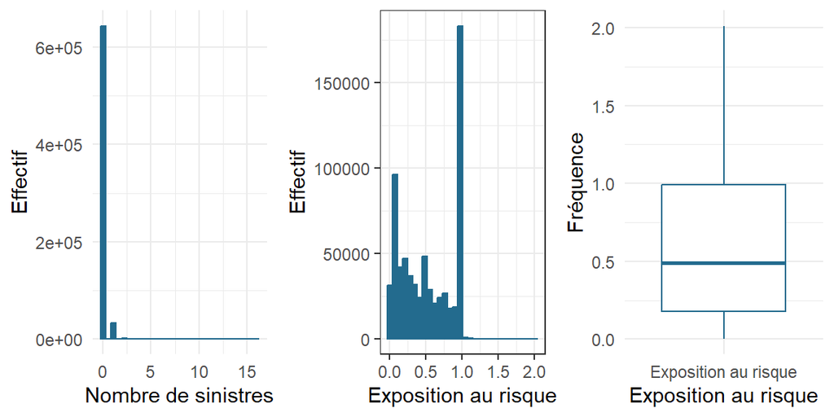

```r
# Création des graphiques pour visualiser la distribution de l'exposition au risque (Exposure) et du nombre de sinistres (ClaimNb)
p1 <- ggplot(freMTPL2freq, aes(Exposure)) +
  geom_histogram(color = "#236B8E", fill = "#236B8E", bins = 30) +
  labs(x = "Exposition au risque", y = "Effectif") +
  theme_bw() +
  theme(plot.title = element_text(size = 12, face = "bold.italic")  )
p2 <- ggplot(freMTPL2freq, aes(x = "Exposition au risque", y = Exposure)) +
  geom_boxplot(color = "#236B8E", fill = "white") +
  labs(x = "Exposition au risque", y = "Fréquence") +
  theme_minimal() +
  theme(plot.title = element_text(size = 12, face = "bold.italic") )
p3 <- ggplot(freMTPL2freq, aes(ClaimNb)) +
  geom_histogram(color = "#236B8E", fill = "#236B8E", bins = 30) +
  labs(x = "Nombre de sinistres", y = "Effectif") +
  theme_minimal() +
  theme( plot.title = element_text(size = 12, face = "bold.italic")  )
# Afficher les graphiques en 3 colonnes
grid.arrange(p3, p1, p2, ncol = 3)
```

## 2.5 Nombre de sinistres et Fréquences de sinstres

```r
# Calculer la fréquence des sinistres du portefeuille
pf_freq <- sum(freMTPL2freq$ClaimNb) / sum(freMTPL2freq$Exposure)
# Fréquence des sinistres du portefeuille (estimation homogène)
sprintf("Fréquence des sinistres du portefeuille :  %s", round(pf_freq, 5))
```

```
## [1] "Fréquence des sinistres du portefeuille :  0.1007"
```

```r
# Grouper par le nombre de sinistres et calculer le nombre total de polices dans chaque groupe
portf_gs <- freMTPL2freq %>%
  group_by(ClaimNb) %>%
  summarize(Nombre_de_polices = n()) %>%
  mutate(Proportion = round(Nombre_de_polices*100 /sum(Nombre_de_polices),2))
# Renommer les colonnes du tableau
names(portf_gs) <- c("Nombre de sinistres", "Nombre total de sinistres", "Proportion (en %)")
# Afficher le tableau
knitr::kable(portf_gs)
```

| Nombre de sinistres | Nombre total de sinistres | Proportion (en %) |
| --- | --- | --- |
| 0 | 643953 | 94.98 |
| 1 | 32178 | 4.75 |
| 2 | 1784 | 0.26 |
| 3 | 82 | 0.01 |
| 4 | 7 | 0.00 |
| 5 | 2 | 0.00 |
| 6 | 1 | 0.00 |
| 8 | 1 | 0.00 |
| 9 | 1 | 0.00 |
| 11 | 3 | 0.00 |
| 16 | 1 | 0.00 |

Les variables catégorielles ici sont répertoriées comme des facteurs. Nous avons converti le type de la variable “ClaimNb” qui était de type tableau en type numérique pour faciliter l’analyse ultérieure.

## 2.6 Prétraitement initial des données

```r
# Convertir la variable VehGas en facteur
freMTPL2freq <- freMTPL2freq %>%
  mutate(VehGas = factor(VehGas),
         ClaimNb = as.integer(ClaimNb),
         Density = round(log(Density), 3))
```

## 2.7 Analyse des données (statistiques descriptives)

```r
# Afficher la structure des données
str(freMTPL2freq)
```

```
## 'data.frame':    678013 obs. of  12 variables:
##  $ IDpol     : num  1 3 5 10 11 13 15 17 18 21 ...
##  $ ClaimNb   : int  1 1 1 1 1 1 1 1 1 1 ...
##  $ Exposure  : num  0.1 0.77 0.75 0.09 0.84 0.52 0.45 0.27 0.71 0.15 ...
##  $ VehPower  : int  5 5 6 7 7 6 6 7 7 7 ...
##  $ VehAge    : int  0 0 2 0 0 2 2 0 0 0 ...
##  $ DrivAge   : int  55 55 52 46 46 38 38 33 33 41 ...
##  $ BonusMalus: int  50 50 50 50 50 50 50 68 68 50 ...
##  $ VehBrand  : Factor w/ 11 levels "B1","B10","B11",..: 4 4 4 4 4 4 4 4 4 4 ...
##  $ VehGas    : Factor w/ 2 levels "Diesel","Regular": 2 2 1 1 1 2 2 1 1 1 ...
##  $ Area      : Factor w/ 6 levels "A","B","C","D",..: 4 4 2 2 2 5 5 3 3 2 ...
##  $ Density   : num  7.1 7.1 3.99 4.33 4.33 ...
##  $ Region    : Factor w/ 21 levels "Alsace","Aquitaine",..: 21 21 18 2 2 16 16 13 13 17 ...
```

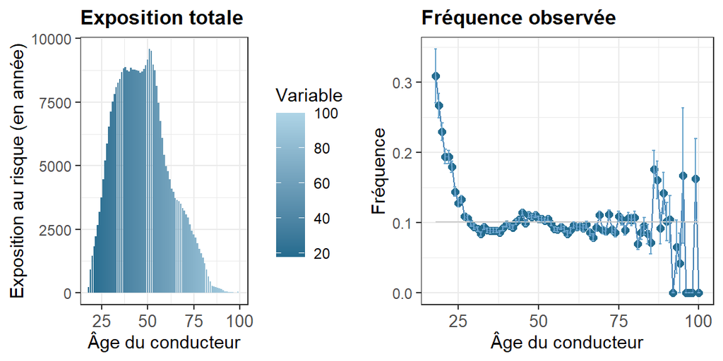

```r
# Calculer la fréquence des sinistres du portefeuille
pf_freq <- sum(freMTPL2freq$ClaimNb) / sum(freMTPL2freq$Exposure)
# Afficher les graphiques exploratoires pour les variables catégorielles
M1 <- multiPlot(freMTPL2freq, "DrivAge", "Âge du conducteur")
```

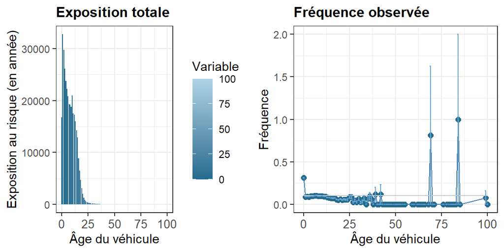

```r
M2 <- multiPlot(freMTPL2freq, "VehAge", "Âge du véhicule")
```

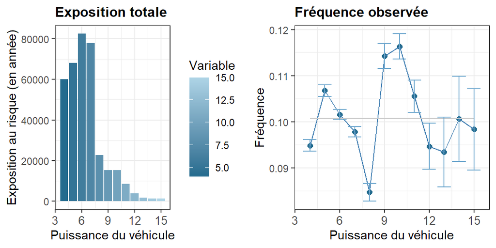

```r
M3 <- multiPlot(freMTPL2freq, "VehPower", "Puissance du véhicule")
```

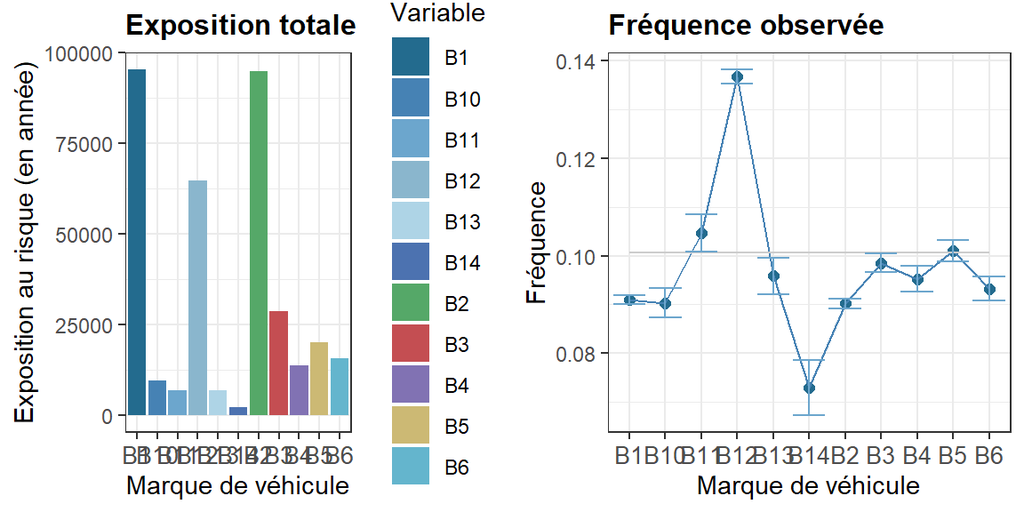

```r
M4 <- multiPlotD(freMTPL2freq, "VehBrand", "Marque de véhicule")
```

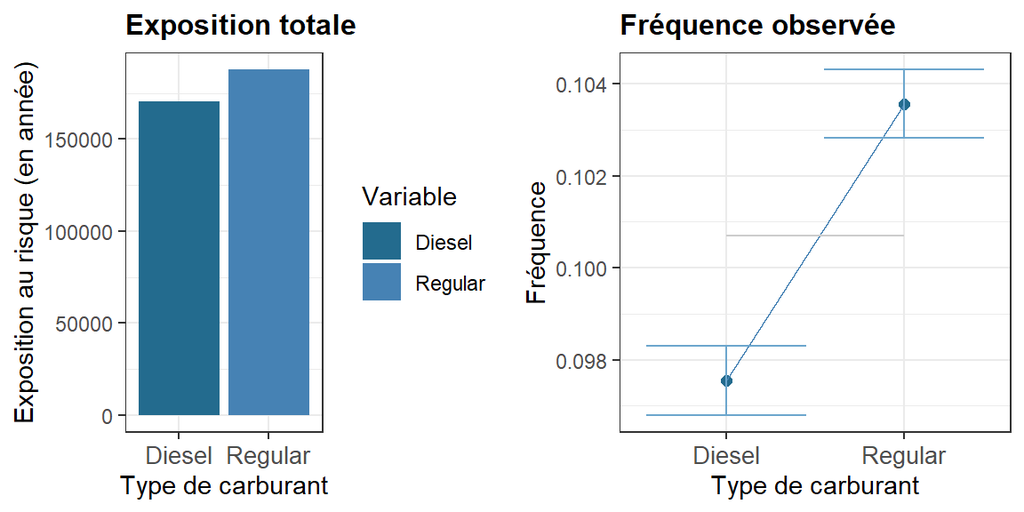

```r
M5 <- multiPlotD(freMTPL2freq, "VehGas", "Type de carburant")
```

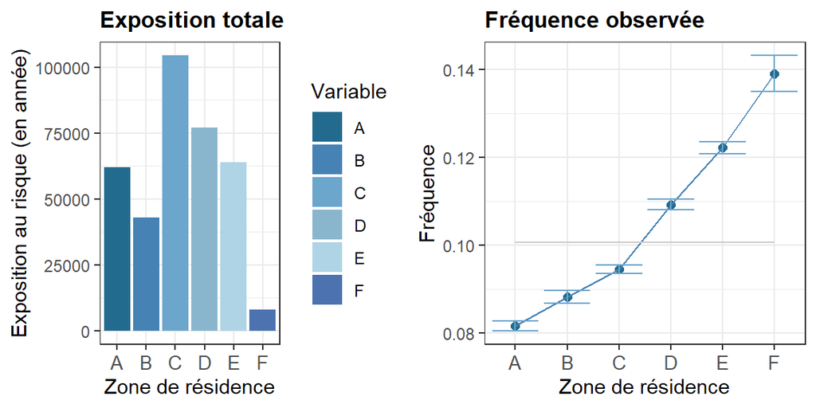

```r
M6 <- multiPlotD(freMTPL2freq, "Area", "Zone de résidence")
```

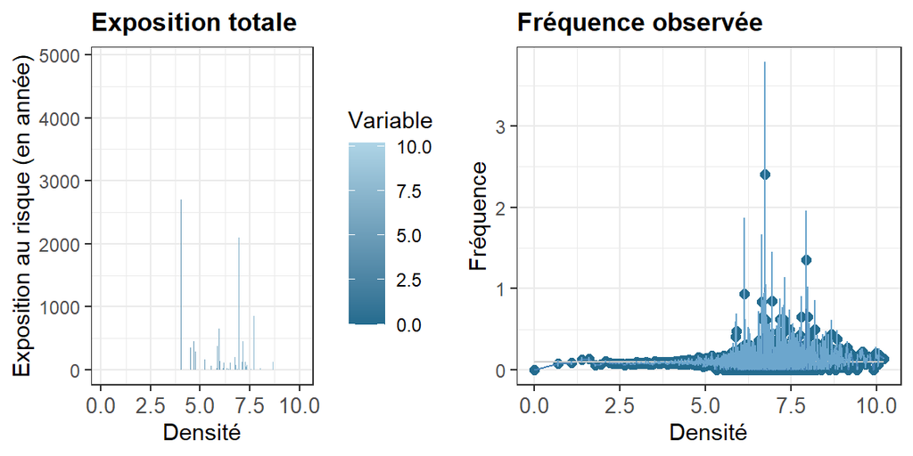

```r
M7 <- multiPlot(freMTPL2freq, "Density", "Densité")
```

[figure not shown]

```r
# Afficher les graphiques exploratoires en plusieurs colonnes
grid.arrange(M1, M2, M3, M4, ncol = 2)
```

[figure not shown]

```r
grid.arrange(M5, M6, M7, ncol = 2)
```

La variable `Exposition` est un peu étrange - il semble étrange d’avoir des polices dont la durée est supérieure à un an (sans contexte spécifique). Dans le cadre de notre analyse nous avons jugé préférable de traiter ces valeurs anormales et potentiellement erronées.

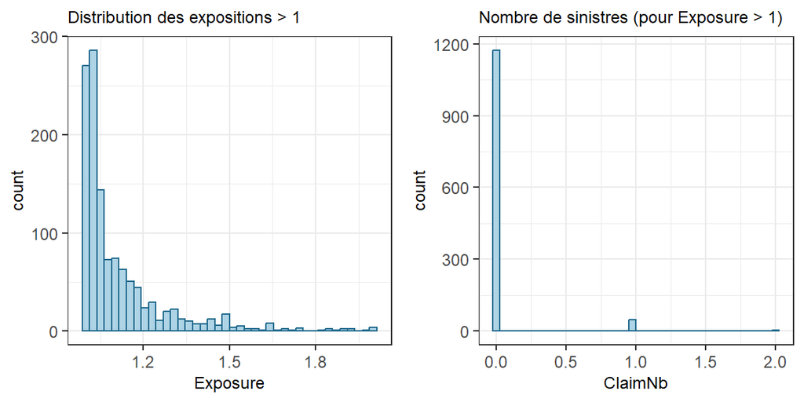

```r
# Filtrer les polices avec une exposition supérieure à 1 an
etran <- freMTPL2freq %>% filter(Exposure > 1)
p1 <- ggplot(etran, aes(Exposure)) +
  geom_histogram(bins = 40, color = "#236B8E", fill = "#AED4E6") +
  ggtitle("Distribution des expositions > 1") +
  theme_bw() +
  theme(
    axis.title = element_text(size = 9),
    axis.text = element_text(size = 9),
    plot.title = element_text(size = 9))
p2 <- ggplot(etran, aes(ClaimNb)) +
  geom_histogram(bins = 40, color = "#236B8E", fill = "#AED4E6") +
  ggtitle("Nombre de sinistres (pour Exposure > 1)") +
  theme_bw() +
  theme(
    axis.title = element_text(size = 9),
    axis.text = element_text(size = 9),
    plot.title = element_text(size = 9))
# Afficher les graphiques côte à côte
grid.arrange(p1, p2, ncol = 2)
```

## 2.8 Corrélation

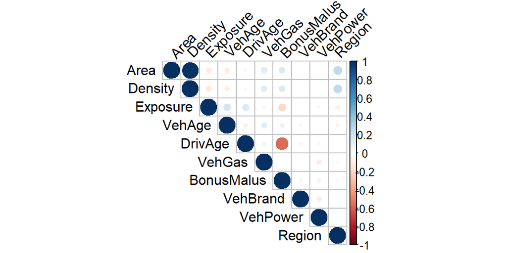

```r
# Calculer la matrice de corrélation de Spearman
M <- round(cor(Numprocess(freMTPL2freq), method = "spearman"), 2)
corrplot::corrplot(M, type = "upper", order = "hclust", tl.col = "black", tl.srt = 45, hclust.method = "ward.D")
```

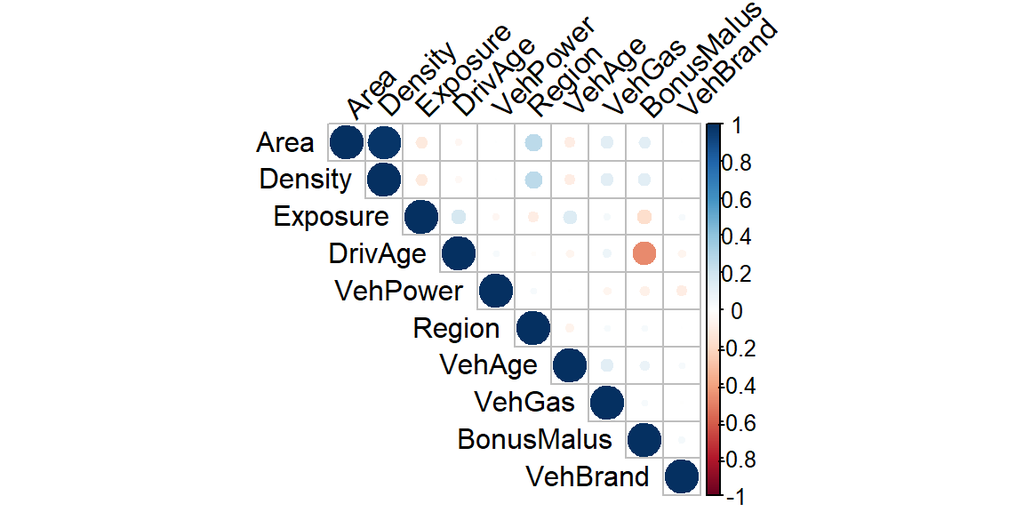

```r
# Calculer la matrice de corrélation de Pearson
M <- round(cor(Numprocess(freMTPL2freq), method = "pearson"), 2)
corrplot::corrplot(M, type = "upper", order = "hclust", tl.col = "black", tl.srt = 45, hclust.method = "ward.D")
```

Ces étapes permettent d’effectuer une exploration préliminaire des données et d’identifier des aspects importants tels que la fréquence des sinistres dans le portefeuille et les corrélations entre les variables. Les graphiques et les analyses de corrélation fournissent une meilleure compréhension des caractéristiques du jeu de données et aident à orienter les analyses et les modélisations ultérieures.

# 3 Sépartion du jeu de données

```r
# Séparation du jeu de données en ensembles d'apprentissage, de test et de validation
ids <- partition(freMTPL2freq$ClaimNb, p = c(train = 0.6, valid = 0.2, test = 0.2), seed = seed)
dl = freMTPL2freq[ids$train,]
dt = freMTPL2freq[ids$test,]
dv = freMTPL2freq[ids$valid,]

# Exclusion des polices d'assurance avec une durée d'exposition supérieure à un an.
datalearning <- dl[dl$Exposure <= 1,]
datatest <- dt[dt$Exposure <= 1,]
datavalid <- dv[dv$Exposure <= 1,]
#En filtrant les polices avec une exposition inférieure ou égale à un an, nous nous concentrons sur les données les plus pertinentes pour l'analyse. Cela nous permet d'éviter toute distorsion due aux valeurs atypiques dans la variable Exposition et de travailler sur des données plus représentatives du portefeuille d'assurance automobile.

# Uniformisation de l'exposition pour chaque ensemble (la variable Exposure est mise à 1)
datalearning_1 <- unif(datalearning)
datatest_1 <- unif(datatest)
datavalid_1 <- unif(datavalid)

# Calcul des proportions de sinistres par rapport à l'exposition dans chaque ensemble
prop_claim_datalearning <- sum(datalearning$ClaimNb) / sum(datalearning$Exposure)
prop_claim_datatest <- sum(datatest$ClaimNb) / sum(datatest$Exposure)
prop_claim_datavalid <- sum(datavalid$ClaimNb) / sum(datavalid$Exposure)

prop_claim_datalearning
```

```
## [1] 0.100329
```

```r
prop_claim_datatest
```

```
## [1] 0.104051
```

```r
prop_claim_datavalid
```

```
## [1] 0.09964636
```

Ces proportions peuvent être utiles pour évaluer la fréquence des sinistres dans chaque ensemble et s’assurer de leur représentativité dans l’ensemble des données.

# 4 Modélisation

## 4.1 Modèle Linéaire Généralisé (GLM) & Modèle Additif Généralisé (GAM)

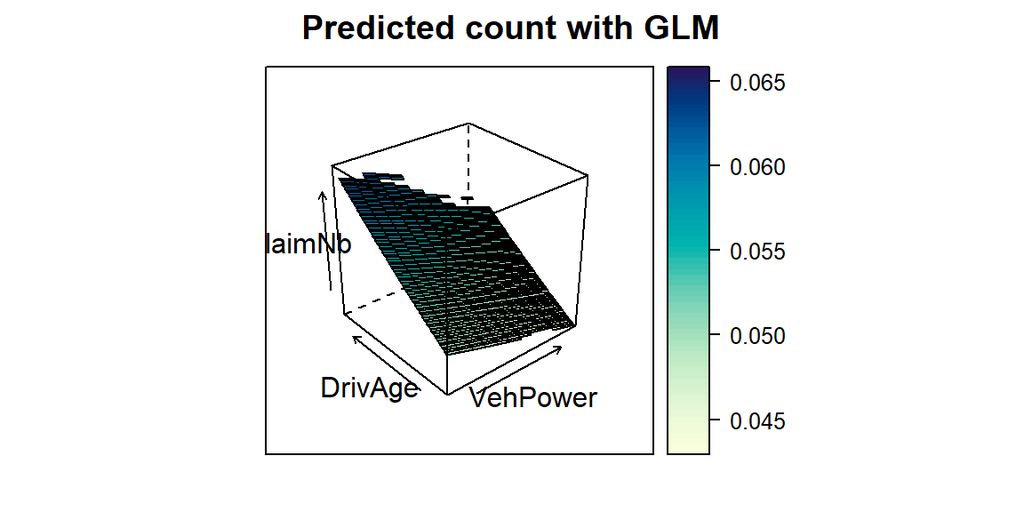

```r
# Modèle GLM de base
Model_0 <- glm(ClaimNb ~ 1 + offset(log(Exposure)), family = poisson, data = datalearning)

# Modèle GLM avec des variables explicatives
Model_glm <- glm(ClaimNb ~ VehPower + DrivAge, family = poisson, data = datalearning)

# Modèle GAM avec des variables explicatives lissées
Model_gam <- gam(ClaimNb ~ s(DrivAge) + s(VehPower), family = poisson, data = datalearning)

# Graphique prédiction GLM
x_tilde <- datalearning
x_tilde$ClaimNb <- predict(Model_glm, x_tilde, type = "response")
wireframe(ClaimNb ~ VehPower + DrivAge, data = x_tilde,
          xlab = "VehPower",
          ylab = "DrivAge",
          main = "Predicted count with GLM",
          drape = TRUE,
          colorkey = TRUE)
```

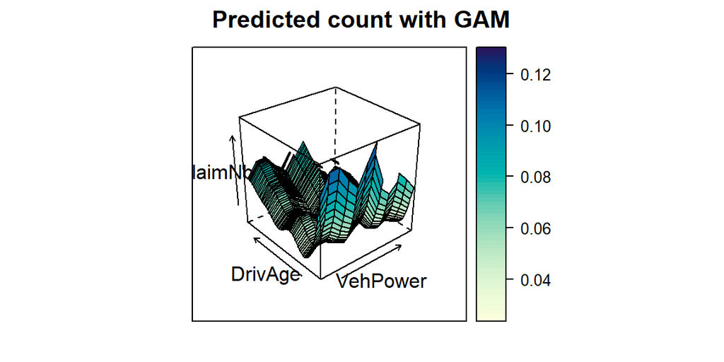

```r
# Graphique prédiction GAM
x_tilde <- datalearning
x_tilde$ClaimNb <- predict(Model_gam, x_tilde, type = "response")
wireframe(ClaimNb ~ VehPower + DrivAge, data = x_tilde,
          xlab = "VehPower",
          ylab = "DrivAge",
          main = "Predicted count with GAM",
          drape = TRUE,
          colorkey = TRUE)
```

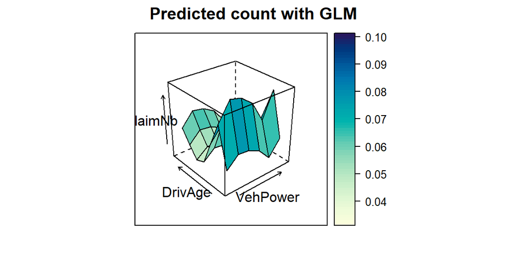

```r
# Modèle GLM avec des variables explicatives transformées
Model_GLM. <- glm(ClaimNb ~ VehPowerGLM + DrivAgeGLM, family = poisson, data = GLMprocess(datalearning))

# Graphique prédiction GLM avec des variables transformées
x_tilde <- GLMprocess(datalearning)
x_tilde$ClaimNb <- predict(Model_GLM., x_tilde, type = "response")
wireframe(ClaimNb ~ VehPowerGLM + DrivAgeGLM, data = x_tilde,
          xlab = "VehPower",
          ylab = "DrivAge",
          main = "Predicted count with GLM",
          drape = TRUE,
          colorkey = TRUE)
```

### 4.1.1 Selection

```r
Model_0 = glm(ClaimNb~ 1 + offset(log(Exposure)), family=poisson,data=datalearning)

# Modèle GLM de base (GLM)
Model_GLM = glm(ClaimNb ~ VehPower + VehAge + DrivAge + BonusMalus + Density + VehBrand + VehGas + Area + Region + offset(log(Exposure)), family = poisson, data = datalearning)
datalearning$GLM <- predict(Model_GLM, newdata = datalearning, type = "response")
datatest$GLM <- predict(Model_GLM, newdata = datatest, type = "response")
datavalid$GLM <- predict(Model_GLM, newdata = datavalid, type = "response")

comp_tab[1, ] <- list("GLM", round(PoissonDeviance(datalearning$ClaimNb, datalearning$GLM), 6),
                     round(PoissonDeviance(datavalid$ClaimNb, datavalid$GLM), 6),
                     round(PoissonDeviance(datatest$ClaimNb, datatest$GLM), 6), AIC(Model_GLM), BIC(Model_GLM))

# Modèle GLM avec discrétisation (GLM avec discrétisation)
Model_GLM_ = glm(ClaimNb ~ VehPowerGLM + VehAgeGLM + BonusMalusGLM + VehBrand + VehGas + DensityGLM + Region + Area + DrivAgeGLM + offset(log(Exposure)), family = poisson, data = GLMprocess(datalearning))
datalearning$GLM_ <- predict(Model_GLM_, newdata = GLMprocess(datalearning), type = "response")
datatest$GLM_ <- predict(Model_GLM_, newdata = GLMprocess(datatest), type = "response")
datavalid$GLM_ <- predict(Model_GLM_, newdata = GLMprocess(datavalid), type = "response")

comp_tab[2, ] <- list("GLM (avec discrétisation)", round(PoissonDeviance(datalearning$ClaimNb, datalearning$GLM_), 6),
                     round(PoissonDeviance(datavalid$ClaimNb, datavalid$GLM_), 6),
                     round(PoissonDeviance(datatest$ClaimNb, datatest$GLM_), 6), AIC(Model_GLM_), BIC(Model_GLM_))

# Modèle GAM (GAM)
Model_GAM = gam(ClaimNb ~ s(VehPower) + s(VehAge) + s(DrivAge) + s(BonusMalus) + s(Density) + VehBrand + VehGas + Area + Region + offset(log(Exposure)), family = poisson, data = datalearning)
datalearning$GAM <- predict(Model_GAM, newdata = datalearning, type = "response")
datatest$GAM <- predict(Model_GAM, newdata = datatest, type = "response")
datavalid$GAM <- predict(Model_GAM, newdata = datavalid, type = "response")

comp_tab[3, ] <- list("GAM", round(PoissonDeviance(datalearning$ClaimNb, datalearning$GAM), 6),
                     round(PoissonDeviance(datatest$ClaimNb, datatest$GAM), 6),
                     round(PoissonDeviance(datavalid$ClaimNb, datavalid$GAM), 6), AIC(Model_GAM), BIC(Model_GAM))

# Résumé des modèles
# summary(Model_GLM)
# summary(Model_GLM_)
# summary(Model_GAM)

# Affichage du tableau comparatif
knitr::kable(comp_tab)
```

[output not shown]

### 4.1.2 Comparaison GLM, GLM avec discrétisation, et GAM

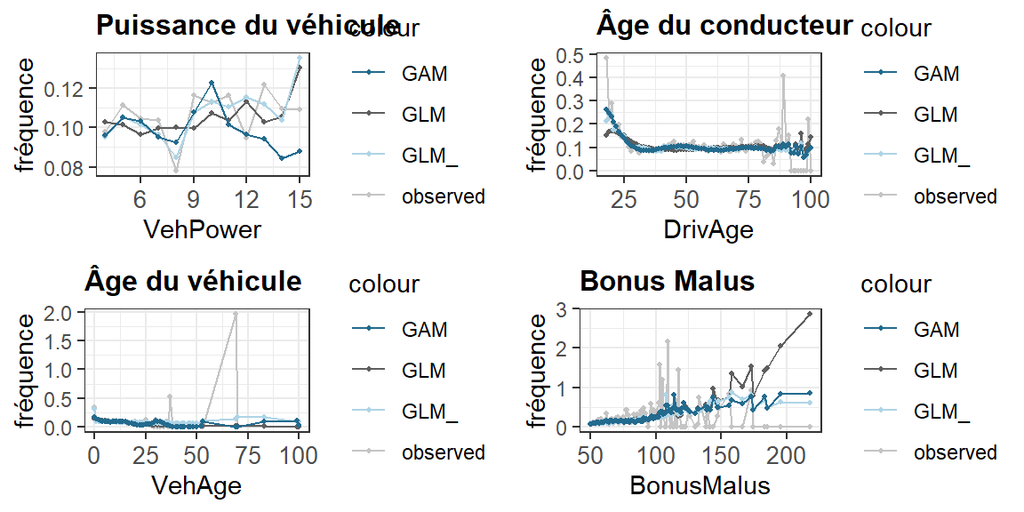

```r
comp_plots1(datatest, "GLM", "GLM_", "GAM")
```

## 4.2 GBM tuning

```r
# set.seed(seed)
# tuning_grid = expand.grid(interaction.depth = 1:10, n.minobsinnode =1, shrinkage= 0.01)
# features <- names(datalearning)[4:12]
# formul <- as.formula(paste("ClaimNb ~",paste(features[!features %in% "datalearning"], collapse = " + "), paste(" + offset(log(Exposure)) ")))
# gbm.res = list()
# library(progress) # package needed for progress bar
# pb <- progress_bar$new(total = nrow(tuning_grid))
# for (nb.it in 1:nrow(tuning_grid)){
# pb$tick()
# set.seed(seed)
# gbm.res[[nb.it]] <- gbm3::gbmt(formul,
# data=datalearning,
# var_monotone=rep(0,length=9),
# distribution=gbm_dist("Poisson"),
# train_params = training_params(
# num_trees = 15000,
# shrinkage=tuning_grid[nb.it,]$shrinkage,
# interaction_depth=tuning_grid[nb.it,]$interaction.depth,
# bag_fraction = 0.5,
# num_train = 1*nrow(datalearning),
# min_num_obs_in_node = tuning_grid[nb.it,]$n.minobsinnode),
# keep_gbm_data = TRUE,
# par_details = gbmParallel(num_threads = 10),
# is_verbose = TRUE,
# cv_folds = 10)
# Sys.sleep(1/nrow(tuning_grid)) }
# save(gbm.res, file = "GBM_tuning")
```

```r
# Définition de la grille de recherche des hyperparamètres
tuning_grid = expand.grid(interaction.depth = 1:10, n.minobsinnode = 1, shrinkage = 0.01)

# Chargement des résultats de tuning GBM préalablement sauvegardés (pour gagner du temps)
load("GBM_tuning")

# Visualisation des performances des modèles GBM avec différentes valeurs d'hyperparamètres
par(mfrow = c(1, 3))
plot(gbmt_performance(gbm.res[[10]], method = "cv"))
nb.trees.opt = vector(length = nrow(tuning_grid))
for (nb.it in 1:nrow(tuning_grid)) {
  nb.trees.opt[nb.it] <- print(gbmt_performance(gbm.res[[nb.it]], method = "cv"))}
```

```
## The best cross-validation iteration was 14999.
## The best cross-validation iteration was 14978.
## The best cross-validation iteration was 14657.
## The best cross-validation iteration was 13874.
## The best cross-validation iteration was 7221.
## The best cross-validation iteration was 5081.
## The best cross-validation iteration was 4779.
## The best cross-validation iteration was 3802.
## The best cross-validation iteration was 3453.
## The best cross-validation iteration was 3601.
```

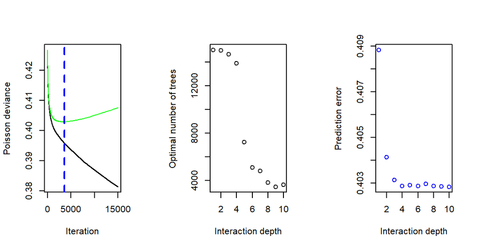

```r
plot(nb.trees.opt, xlab = "Interaction depth", ylab = "Optimal number of trees")
pred.error = vector(length = nrow(tuning_grid))
for (nb.it in 1:nrow(tuning_grid)) {
  pred.error[nb.it] <- gbm.res[[nb.it]]$cv_error[nb.trees.opt[nb.it]]}
plot(pred.error, xlab = "Interaction depth", ylab = "Prediction error", col = "blue")
```

```r
par(mfrow = c(1, 1))
```

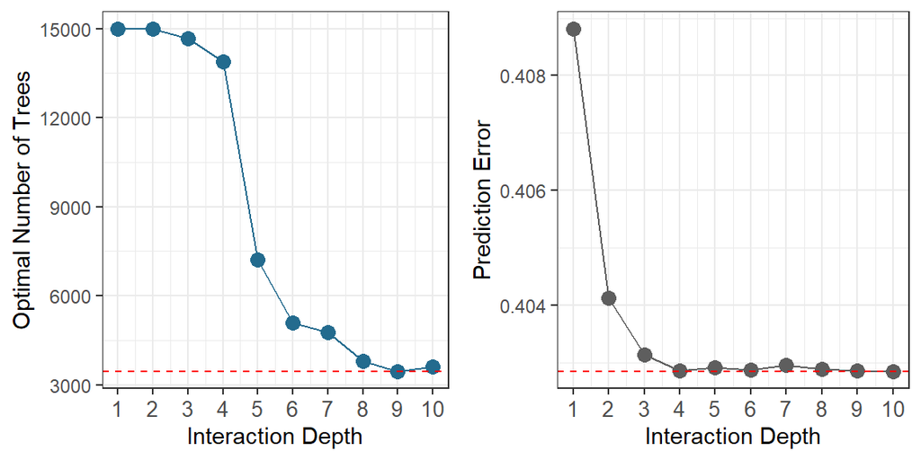

```r
# Création du data.frame pour les graphiques
df <- data.frame(
  Interaction_Depth = 1:nrow(tuning_grid),
  Optimal_Number_of_Trees = nb.trees.opt,
  Prediction_Error = pred.error)

# Graphique 1 - Nombre optimal d'arbres
p1 <- ggplot(df, aes(x = Interaction_Depth, y = Optimal_Number_of_Trees)) +
  geom_line(colour = clrpal[1]) +
  geom_point(colour = clrpal[1], size = 3) +
  geom_hline(yintercept = min(nb.trees.opt), colour = "red", linetype = "dashed") +
  labs(x = "Interaction Depth", y = "Optimal Number of Trees") +
  theme_bw() +
  theme(
    plot.title = element_text(size = 12, face = "bold"),
    axis.text.x = element_text(size = 10)
  ) +
  scale_x_continuous(breaks = seq(1, nrow(tuning_grid), 1))

# Graphique 2 - Erreur de prédiction
p2 <- ggplot(df, aes(x = Interaction_Depth, y = Prediction_Error)) +
  geom_line(colour = clrpal[2]) +
  geom_point(colour = clrpal[2], size = 3) +
  geom_hline(yintercept = min(pred.error), colour = "red", linetype = "dashed") +
  labs(x = "Interaction Depth", y = "Prediction Error") +
  theme_bw() +
  theme(
    plot.title = element_text(size = 12, face = "bold"),
    axis.text.x = element_text(size = 10)) +
  scale_x_continuous(breaks = seq(1, nrow(tuning_grid), 1))

# Affichage côte à côte des graphiques
grid.arrange(p1, p2, ncol = 2)
```

```r
# GBM Final
features <- names(datalearning)[4:12]
formul <- as.formula(paste("ClaimNb ~",paste(features[!features %in% "datalearning"], collapse = " + "), paste(" + offset(log(Exposure)) ")))
nb.trees.fin <- nb.trees.opt[which(pred.error == min(pred.error))]
best.iter <- which(pred.error == min(pred.error))
set.seed(seed)
GBM <- gbmt(formul,
data=datalearning,
var_monotone=rep(0,length=9),
distribution=gbm_dist("Poisson"),
train_params = training_params(
num_trees = nb.trees.fin,
shrinkage=0.01,
interaction_depth=best.iter,
bag_fraction = 0.5,
num_train = 1*nrow(datalearning),
min_num_obs_in_node = 1),
keep_gbm_data = TRUE,
par_details = gbmParallel(num_threads = 2),
is_verbose = FALSE)
```

### 4.2.1 Importances relatives et dépendance partielle

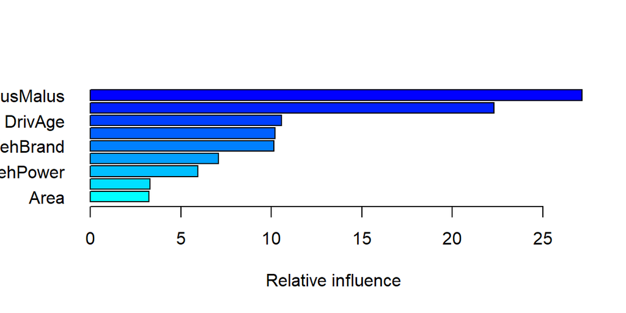

```
##                   var   rel_inf
## BonusMalus BonusMalus 27.161341
## VehAge         VehAge 22.302340
## DrivAge       DrivAge 10.577316
## Region         Region 10.212314
## VehBrand     VehBrand 10.138920
## Density       Density  7.090605
## VehPower     VehPower  5.953481
## VehGas         VehGas  3.307851
## Area             Area  3.255833
```

```r
# Afficher le résumé de l'importance des variables
summary(GBM)
```

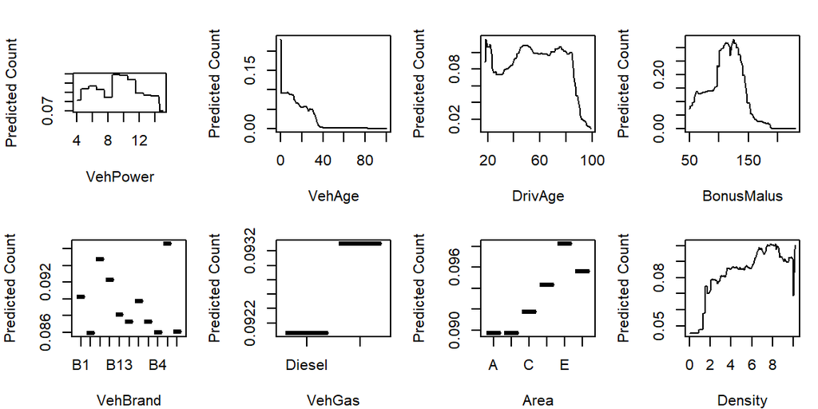

```r
# Configuration du tracé en plusieurs colonnes
par(mfrow = c(2, 4))

# Parcours des variables et création des graphiques
for (i in 1:length(features)) {
  # Création du graphique avec plot()
  plot(GBM, var_index = i, num_trees = nb.trees.fin, type = "response")

  # Modification des paramètres esthétiques
  par(mar = c(4, 4, 2, 1))  # Ajuster les marges
}
```

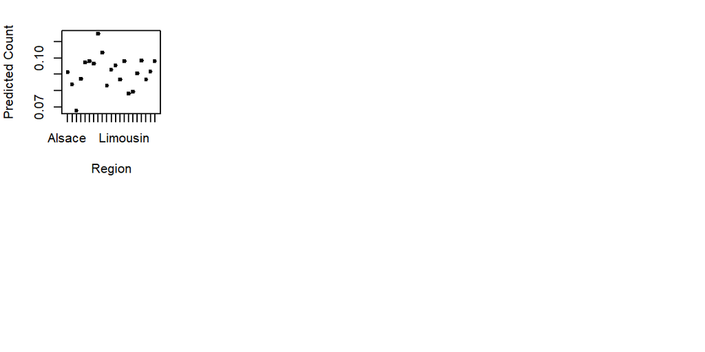

```r
# Rétablir la configuration par défaut
par(mfrow = c(1, 1))
```

### 4.2.2 Interactions

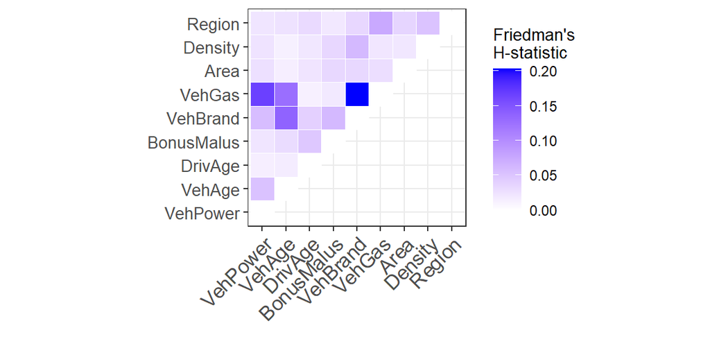

```r
# Création d'une matrice vide de dimension 9x9
# res = matrix(NA, 9, 9)

# Boucles pour évaluer les interactions entre les variables
# for (i in 1:8){
  # for (j in (i + 1):9){
    # Utilisation de la fonction interact pour évaluer l'interaction entre les variables i et j dans le modèle GBM
    # res[i, j] = interact(gbm_fit_obj = GBM, data = datalearning, var_indices = c(i, j), nb.trees.fin)
  # }
# }

# Remplissage de la diagonale de la matrice avec des zéros (car l'interaction d'une variable avec elle-même est nulle)
# diag(res) = 0

# Définition des noms de lignes et de colonnes de la matrice avec les noms des variables (features)
# row.names(res) = features
# colnames(res) = row.names(res)

# Conversion de la matrice en un format long (melt) pour une visualisation plus facile dans un graphique
# interact_melt <- data.table::melt(res, na.rm = TRUE)

load("res_interact")

# Création d'un graphique de type heatmap pour visualiser les interactions entre les variables
ggplot(data = interact_melt, aes(x = Var1, y = Var2, fill = value)) +
  geom_tile(color = "white") +
  scale_fill_gradient2(low = "#AED4E6", high = "blue", name = "Friedman's\nH-statistic") +
  xlab(" ") +
  ylab(" ") +
  theme_bw() +
  theme(axis.text.x = element_text(angle = 45, vjust = 1, size = 12, hjust = 1),
        plot.title = element_text(size = 12, face = "bold"),
        axis.text = element_text(size = 10),
        legend.title = element_text(size = 10)) +
  coord_fixed()
```

### 4.2.3 Comparaison GLM & GAM & GBM

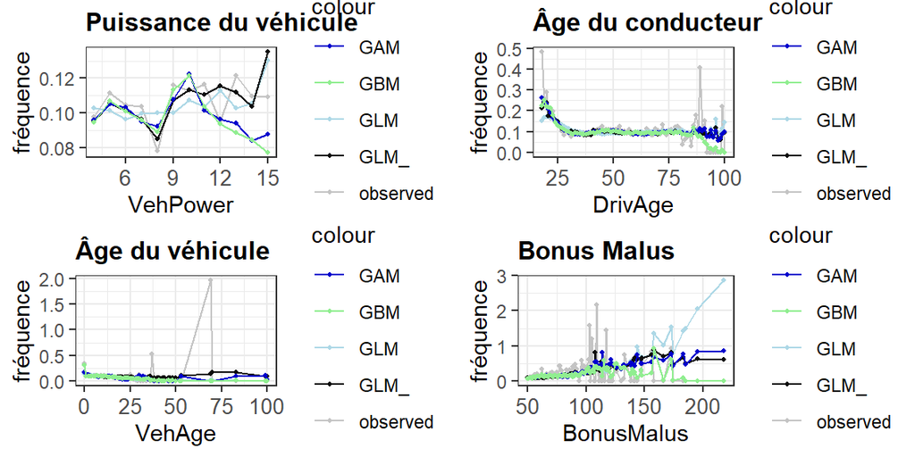

```r
# Prédiction de la variable GBM sur le jeu de données datalearning à l'aide du modèle GBM
datalearning$GBM <- predict(GBM, newdata = datalearning, n.trees = nb.trees.fin, type = "response") * datalearning$Exposure

# Prédiction de la variable GBM sur le jeu de données datatest à l'aide du modèle GBM
datatest$GBM <- predict(GBM, newdata = datatest, n.trees = nb.trees.fin, type = "response") * datatest$Exposure

# Prédiction de la variable GBM sur le jeu de données datavalid à l'aide du modèle GBM
datavalid$GBM <- predict(GBM, newdata = datavalid, n.trees = nb.trees.fin, type = "response") * datavalid$Exposure

# Mise à jour de la ligne 4 de la table comp_tab avec les déviations de Poisson pour GBM
comp_tab[4, ] <- list("GBM", round(PoissonDeviance(datalearning$ClaimNb, datalearning$GBM), 6),
                   round(PoissonDeviance(datatest$ClaimNb, datatest$GBM), 6),
                   round(PoissonDeviance(datavalid$ClaimNb, datavalid$GBM), 6), NaN, NaN)

# Définition des couleurs pour les graphiques de comparaison
clrpal <- c("blue3", "lightgreen", "lightblue", "gray5", "gray77", "gray50", "#6CA6CD", "#8AB6CD", "#1F77B4", "#4682B4", "#4C72B0")

# Affichage des graphiques de comparaison en utilisant la fonction comp_plots2
comp_plots2(datatest, "GLM", "GLM_", "GAM", "GBM")
```

```r
# Affichage de la table comp_tab sous forme de tableau en utilisant la fonction knitr::kable
knitr::kable(comp_tab)
```

| Model | In sample loss (training set) | Out sample loss (validation set) | Out sample loss (test set) | AIC | BIC |
| --- | --- | --- | --- | --- | --- |
| GLM | 0.318888 | 0.317176 | 0.328850 | 170861.3 | 171319.7 |
| GLM (avec discrétisation) | 0.313163 | 0.310890 | 0.321766 | 168556.6 | 169124.1 |
| GAM | 0.316126 | 0.326025 | 0.314636 | 169797.6 | 170570.9 |
| GBM | 0.298511 | 0.313775 | 0.303663 | NaN | NaN |